# Project 1: Vignettes about Reading JSON Files and analysis in R

Min He

June 9, 2020 (updated 2020-06-10)

# 1 JSON Description

JSON (JavaScript Object Notation) is a lightweight data-interchange format. It is easy for humans to read and write. It is easy for machines to parse and generate. JSON is common data formats used to receive data from a web server. JSON is built on two structures:

- A collection of name/value pairs.
- An ordered list of values.

# 2 Pros/Cons of Packages

We chose the `jsonlite` package to read in our data. The `rjson` package was also considered, but inital attempts needed extra code to implement the data into a dataframe. The `jsonlite` package converts read data directly into a dataframes by default, while `rjson` will convert data into a list by default. Given our need to work with dataframes, `jsonlite` performs better for our needs.

# 3 Data

This data we are using is the NHL records, an jsonlite API is used to retrieve all the team data (including the details about team New Jersey Devils).

## 3.1 Read the data

```r
# Read in data from JSON source

read_json<-function(root_url,params){
  json_file <- paste0(root_url,params)
  source_data <- fromJSON(json_file)
  franchise_df <- as.data.frame(source_data$data) #Convert to data frame
  return(franchise_df)
}
root_url <- 'https://records.nhl.com/site/api'
franchise_df <- read_json(root_url,'/franchise')
franchise_team_total <- read_json(root_url,'/franchise-team-totals')

franchise_id=23
franchise_team_season <- read_json(root_url,paste0('/franchise-season-records?cayenneExp=franchiseId=',franchise_id))
franchise_team_goalie <- read_json(root_url,paste0('/franchise-goalie-records?cayenneExp=franchiseId=',franchise_id))
franchise_team_skater <- read_json(root_url,paste0('/franchise-skater-records?cayenneExp=franchiseId=',franchise_id))
```

## 3.2 Basic data exploratory

A basic exploratory data analysis.

- The scatterplot between losses and home losses shows a very good linear relationship
- The linear relationship between losses and home losses still hold within each game type.

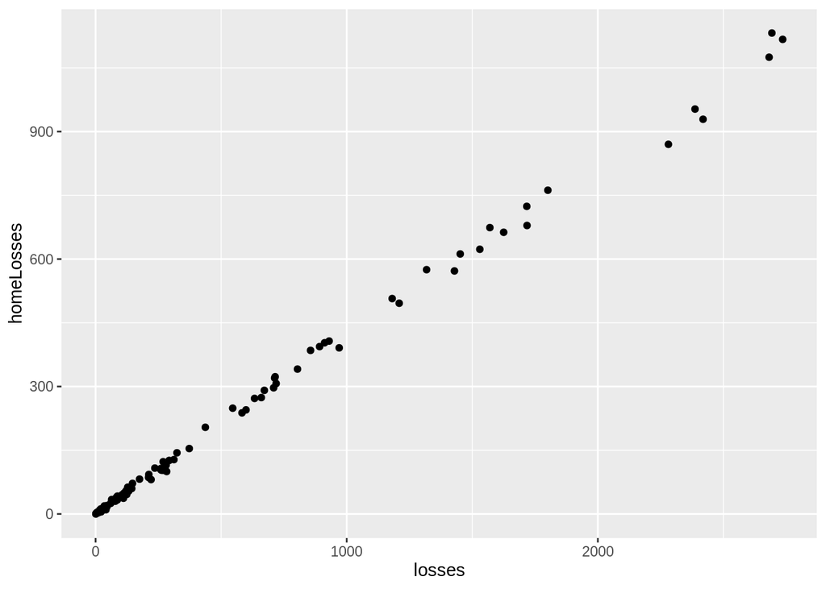

```r
ggplot(franchise_team_total,aes(losses,homeLosses)) +
  geom_point()
```

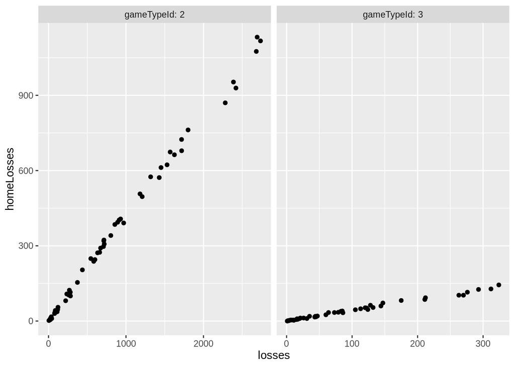

```r
ggplot(franchise_team_total,aes(losses,homeLosses)) +
  geom_point() +
  facet_grid(cols=vars(gameTypeId),scales = "free",labeller = label_both)
```

**Take the** *franchiseId=23* **an an example, the scatterplot between most wins in one season and total wins for each team member shows some linear relationship and this relationship is better when the outlier was excluded.**

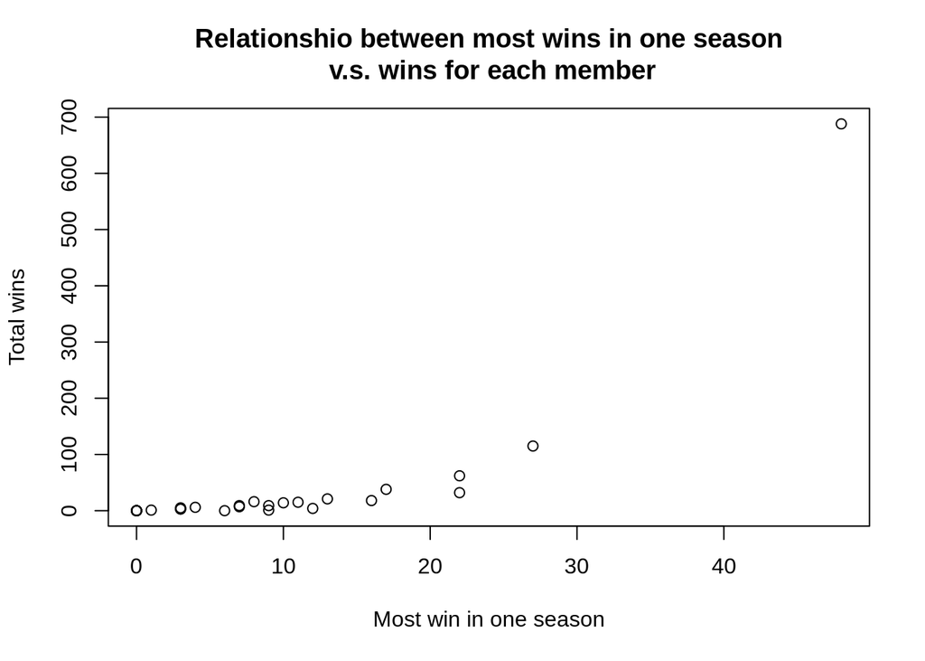

```r
plot(franchise_team_goalie$mostWinsOneSeason, franchise_team_goalie$wins, main='Relationshio between most wins in one season\n v.s. wins for each member', xlab = 'Most win in one season', ylab='Total wins')
```

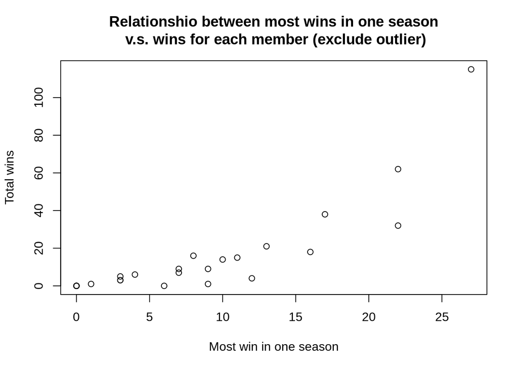

```r
plot(franchise_team_goalie$mostWinsOneSeason[-1], franchise_team_goalie$wins[-1], main='Relationshio between most wins in one season\n v.s. wins for each member (exclude outlier)', xlab = 'Most win in one season', ylab='Total wins')
```

## 3.3 Create Contingency Table

**Show contingency table with columns of team and game type (summarise the total of wins)**

```r
#Function creates Contingency Table
contingencyTable<-franchise_team_total %>% group_by_at(c('teamName','gameTypeId')) %>%
    summarise(wins = sum(wins)) %>%
    spread(key = 'gameTypeId', value = "wins")

kable(contingencyTable)
```

| teamName | 2 | 3 |
| --- | --- | --- |
| Anaheim Ducks | 973 | 89 |
| Arizona Coyotes | 190 | NA |
| Atlanta Flames | 268 | 2 |
| Atlanta Thrashers | 342 | 0 |
| Boston Bruins | 3208 | 321 |
| Brooklyn Americans | 16 | NA |
| Buffalo Sabres | 1790 | 124 |
| Calgary Flames | 1471 | 98 |
| California Golden Seals | 116 | NA |
| Carolina Hurricanes | 791 | 49 |
| Chicago Blackhawks | 2788 | 264 |
| Cleveland Barons | 47 | NA |
| Colorado Avalanche | 968 | 109 |
| Colorado Rockies | 113 | 0 |
| Columbus Blue Jackets | 660 | 11 |
| Dallas Stars | 1061 | 90 |
| Detroit Cougars | 64 | 0 |
| Detroit Falcons | 34 | 0 |
| Detroit Red Wings | 2872 | 325 |
| Edmonton Oilers | 1434 | 159 |
| Florida Panthers | 852 | 18 |
| Hamilton Tigers | 47 | NA |
| Hartford Whalers | 534 | 18 |
| Kansas City Scouts | 27 | NA |
| Los Angeles Kings | 1733 | 111 |
| Minnesota North Stars | 758 | 80 |
| Minnesota Wild | 724 | 26 |
| Montréal Canadiens | 3449 | 429 |
| Montreal Maroons | 271 | 20 |
| Montreal Wanderers | 1 | NA |
| Nashville Predators | 821 | 51 |
| New Jersey Devils | 1375 | 137 |
| New York Americans | 239 | 6 |
| New York Islanders | 1656 | 148 |
| New York Rangers | 2856 | 244 |
| Oakland Seals | 66 | 3 |
| Ottawa Senators | 948 | 72 |
| Ottawa Senators (1917) | 258 | 18 |
| Philadelphia Flyers | 2054 | 221 |
| Philadelphia Quakers | 4 | NA |
| Phoenix Coyotes | 615 | 22 |
| Pittsburgh Penguins | 1866 | 206 |
| Pittsburgh Pirates | 67 | 1 |
| Quebec Bulldogs | 4 | NA |
| Quebec Nordiques | 497 | 35 |
| San Jose Sharks | 1049 | 119 |
| St. Louis Blues | 1902 | 180 |
| St. Louis Eagles | 11 | NA |
| Tampa Bay Lightning | 949 | 73 |
| Toronto Arenas | 18 | 4 |
| Toronto Maple Leafs | 2838 | 254 |
| Toronto St. Patricks | 109 | 4 |
| Vancouver Canucks | 1626 | 101 |
| Vegas Golden Knights | 133 | 16 |
| Washington Capitals | 1664 | 135 |
| Winnipeg Jets | 352 | 11 |
| Winnipeg Jets (1979) | 506 | 19 |

# 4 Plotting

## 4.1 Scatter plot by color

**Scatterplot between the loss and home loss with colored by game type, the results show very good linear relationship.**

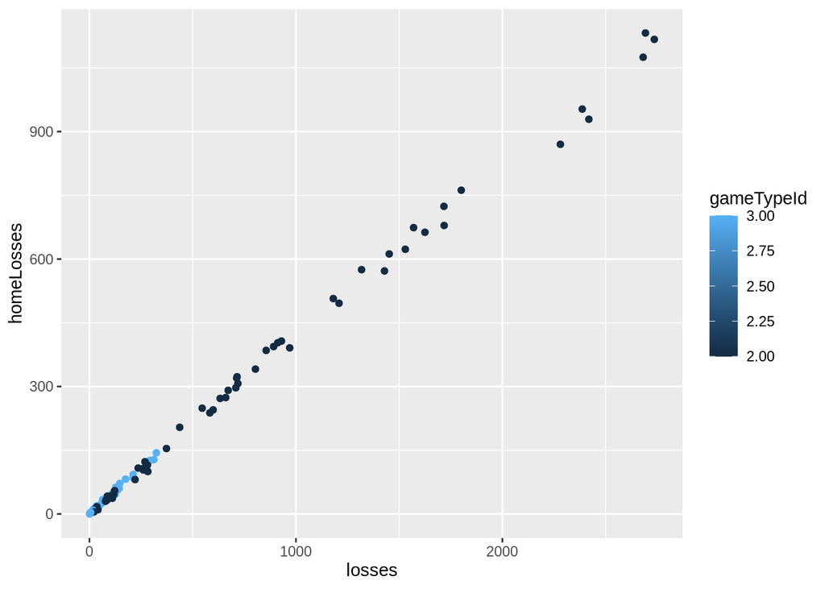

```r
ggplot(franchise_team_total,aes(losses,homeLosses, color=gameTypeId)) +
  geom_point()
```

## 4.2 Histogram plot by side by side

**Plot the histogram of the wins by game type**

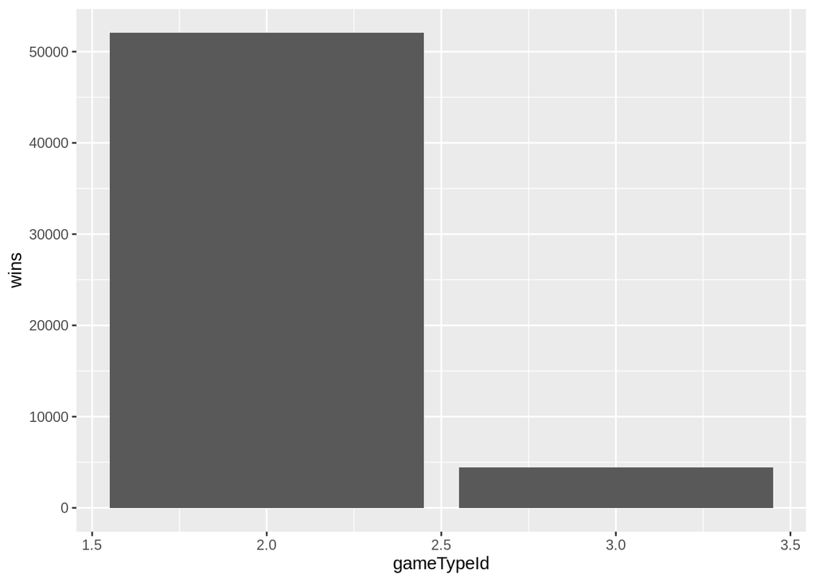

```r
franchise_by_gametype<-franchise_team_total %>% group_by_at(c('teamName','teamId','gameTypeId')) %>%
    summarise(wins = sum(wins), losses=sum(losses))

ggplot(franchise_by_gametype,aes(gameTypeId,wins)) +
  geom_col()
```

**Plot the histogram of the wins for each team (side by side with game type)**, *It shows that when the wins in game type=2 is high, the wins in game type=2 is also high.*

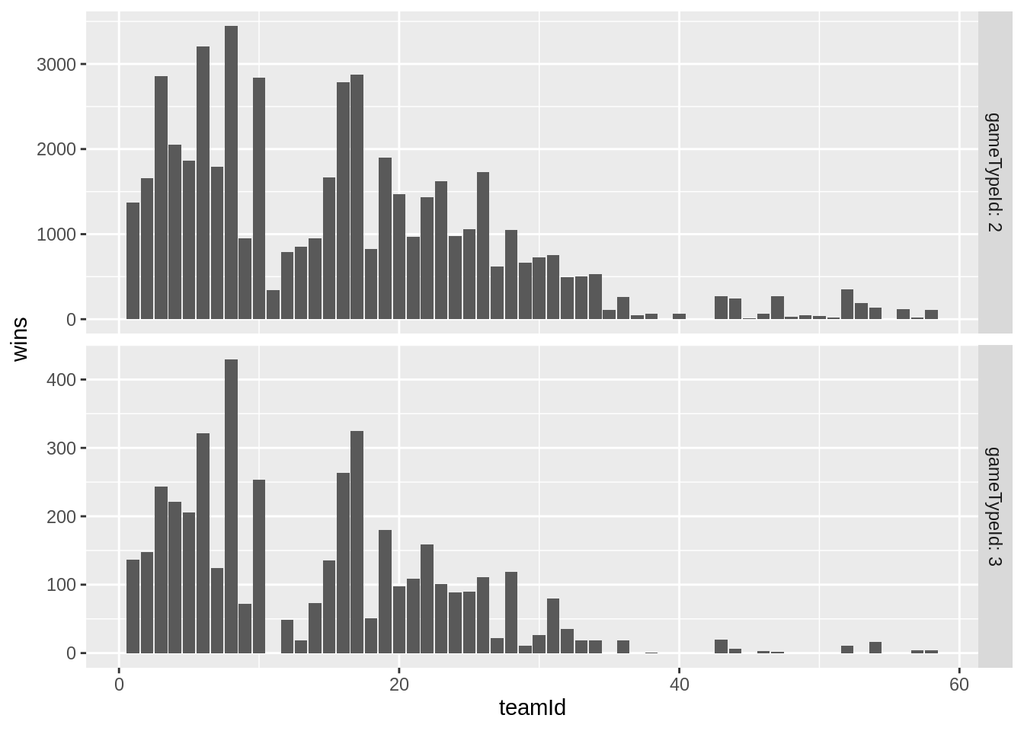

```r
ggplot(franchise_by_gametype,aes(teamId,wins,gameTypeId)) +
  geom_col() +
  facet_grid(rows=vars(gameTypeId), labeller = label_both,scales = "free",)
```